# Analyzing Red,Red Wine

by Michal Nadolny  
Inspired by https://youtu.be/zXt56MB-3vc (Great background music)  
Dataset Details: This tidy data set contains 1,599 red wines with 11 variables on the chemical properties of the wine. At least 3 wine experts rated the quality of each wine, providing a rating between 0 (very bad) and 10 (very excellent). See more information on the data set in this file. In this analysis we will be exploring which of the chemical properties influence the quality of red wines ========================================================

# Univariate Plots Section

```
##  [1] "X"                    "fixed.acidity"        "volatile.acidity"
##  [4] "citric.acid"          "residual.sugar"       "chlorides"
##  [7] "free.sulfur.dioxide"  "total.sulfur.dioxide" "density"
## [10] "pH"                   "sulphates"            "alcohol"
## [13] "quality"
```

```
## 'data.frame':    1599 obs. of  13 variables:
##  $ X                   : int  1 2 3 4 5 6 7 8 9 10 ...
##  $ fixed.acidity       : num  7.4 7.8 7.8 11.2 7.4 7.4 7.9 7.3 7.8 7.5 ...
##  $ volatile.acidity    : num  0.7 0.88 0.76 0.28 0.7 0.66 0.6 0.65 0.58 0.5 ...
##  $ citric.acid         : num  0 0 0.04 0.56 0 0 0.06 0 0.02 0.36 ...
##  $ residual.sugar      : num  1.9 2.6 2.3 1.9 1.9 1.8 1.6 1.2 2 6.1 ...
##  $ chlorides           : num  0.076 0.098 0.092 0.075 0.076 0.075 0.069 0.065 0.073 0.071 ...
##  $ free.sulfur.dioxide : num  11 25 15 17 11 13 15 15 9 17 ...
##  $ total.sulfur.dioxide: num  34 67 54 60 34 40 59 21 18 102 ...
##  $ density             : num  0.998 0.997 0.997 0.998 0.998 ...
##  $ pH                  : num  3.51 3.2 3.26 3.16 3.51 3.51 3.3 3.39 3.36 3.35 ...
##  $ sulphates           : num  0.56 0.68 0.65 0.58 0.56 0.56 0.46 0.47 0.57 0.8 ...
##  $ alcohol             : num  9.4 9.8 9.8 9.8 9.4 9.4 9.4 10 9.5 10.5 ...
##  $ quality             : int  5 5 5 6 5 5 5 7 7 5 ...
```

```
##   X fixed.acidity volatile.acidity citric.acid residual.sugar chlorides
## 1 1           7.4             0.70        0.00            1.9     0.076
## 2 2           7.8             0.88        0.00            2.6     0.098
## 3 3           7.8             0.76        0.04            2.3     0.092
## 4 4          11.2             0.28        0.56            1.9     0.075
## 5 5           7.4             0.70        0.00            1.9     0.076
## 6 6           7.4             0.66        0.00            1.8     0.075
##   free.sulfur.dioxide total.sulfur.dioxide density   pH sulphates alcohol
## 1                  11                   34  0.9978 3.51      0.56     9.4
## 2                  25                   67  0.9968 3.20      0.68     9.8
## 3                  15                   54  0.9970 3.26      0.65     9.8
## 4                  17                   60  0.9980 3.16      0.58     9.8
## 5                  11                   34  0.9978 3.51      0.56     9.4
## 6                  13                   40  0.9978 3.51      0.56     9.4
##   quality
## 1       5
## 2       5
## 3       5
## 4       6
## 5       5
## 6       5
```

```
##        X          fixed.acidity   volatile.acidity  citric.acid
##  Min.   :   1.0   Min.   : 4.60   Min.   :0.1200   Min.   :0.000
##  1st Qu.: 400.5   1st Qu.: 7.10   1st Qu.:0.3900   1st Qu.:0.090
##  Median : 800.0   Median : 7.90   Median :0.5200   Median :0.260
##  Mean   : 800.0   Mean   : 8.32   Mean   :0.5278   Mean   :0.271
##  3rd Qu.:1199.5   3rd Qu.: 9.20   3rd Qu.:0.6400   3rd Qu.:0.420
##  Max.   :1599.0   Max.   :15.90   Max.   :1.5800   Max.   :1.000
##  residual.sugar     chlorides       free.sulfur.dioxide
##  Min.   : 0.900   Min.   :0.01200   Min.   : 1.00
##  1st Qu.: 1.900   1st Qu.:0.07000   1st Qu.: 7.00
##  Median : 2.200   Median :0.07900   Median :14.00
##  Mean   : 2.539   Mean   :0.08747   Mean   :15.87
##  3rd Qu.: 2.600   3rd Qu.:0.09000   3rd Qu.:21.00
##  Max.   :15.500   Max.   :0.61100   Max.   :72.00
##  total.sulfur.dioxide    density             pH          sulphates
##  Min.   :  6.00       Min.   :0.9901   Min.   :2.740   Min.   :0.3300
##  1st Qu.: 22.00       1st Qu.:0.9956   1st Qu.:3.210   1st Qu.:0.5500
##  Median : 38.00       Median :0.9968   Median :3.310   Median :0.6200
##  Mean   : 46.47       Mean   :0.9967   Mean   :3.311   Mean   :0.6581
##  3rd Qu.: 62.00       3rd Qu.:0.9978   3rd Qu.:3.400   3rd Qu.:0.7300
##  Max.   :289.00       Max.   :1.0037   Max.   :4.010   Max.   :2.0000
##     alcohol         quality
##  Min.   : 8.40   Min.   :3.000
##  1st Qu.: 9.50   1st Qu.:5.000
##  Median :10.20   Median :6.000
##  Mean   :10.42   Mean   :5.636
##  3rd Qu.:11.10   3rd Qu.:6.000
##  Max.   :14.90   Max.   :8.000
```

These first couple lines of code allow us to explore the dataset. Shows X is the unique identifier in this dataset and we see the MAX is 1599 which is the count of rows.The median quality is at a 6 while the MIN and MAX are 3 and 8 respectively, but we’ll get into more details on that in just a bit…

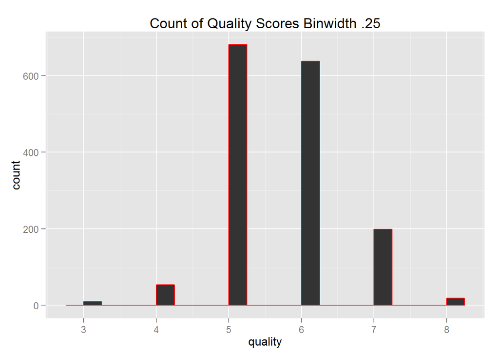

We observe the judges mostly gave out 5 and 6 quality scores.

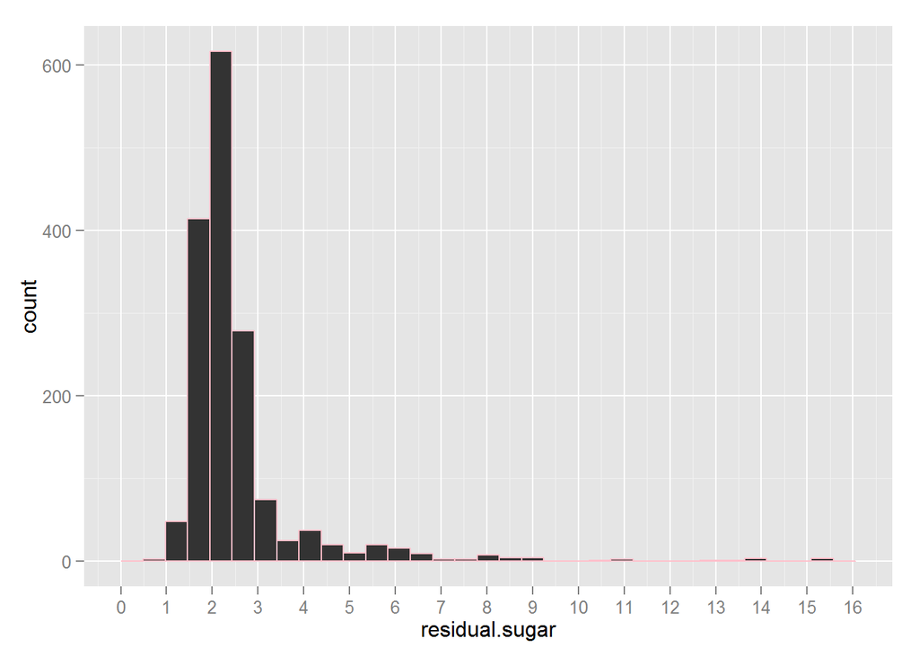

Majority of red wines are not sweet. I’m curious what the scores were of really sweet ones…

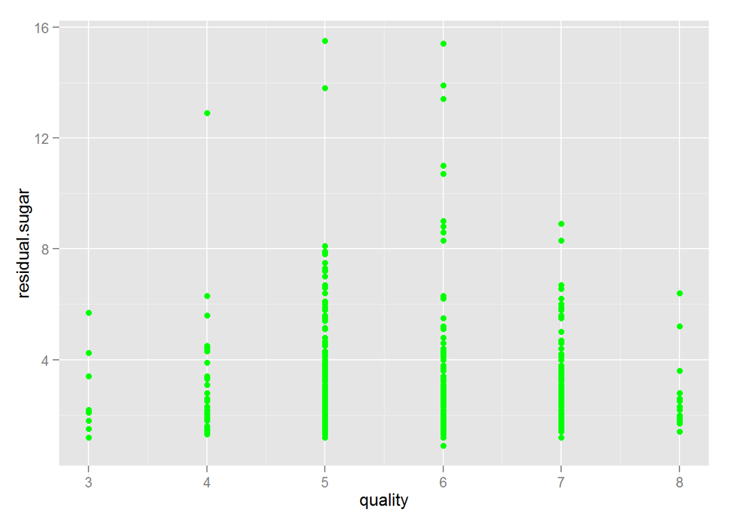

Suprisingly, the outliers with high sugar recieved average 5 and 6 rating just like the rest of them.

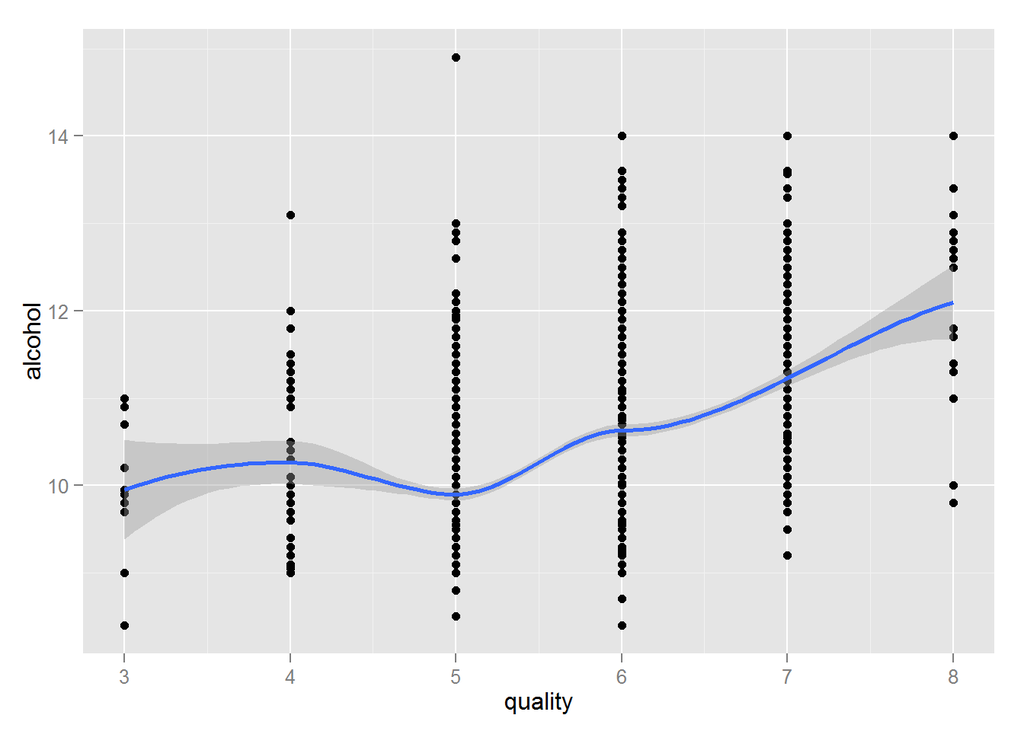

Now we take a look at quality and alcohol, we can see there is linear growth.The dip on 5 is due to the amount of 5 quality rating given out. The numbers for quality =4,5,6 are shown below.

```
##    Mode   FALSE    TRUE    NA's
## logical    1546      53       0
```

```
##    Mode   FALSE    TRUE    NA's
## logical     918     681       0
```

```
##    Mode   FALSE    TRUE    NA's
## logical     961     638       0
```

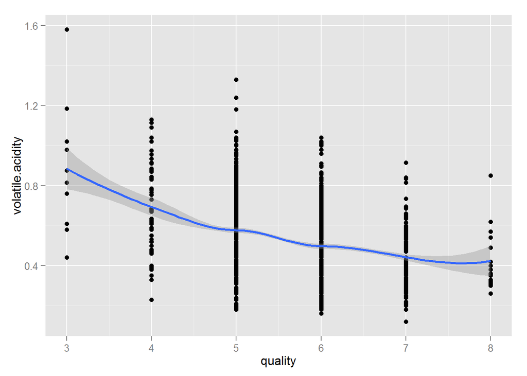

Another feature that will help support investigation is volatile acidity, from the dataset description the amount of acetic acid in wine, which at too high of levels can lead to an unpleasant, vinegar taste. Which I would think would lead to lower quality scores.

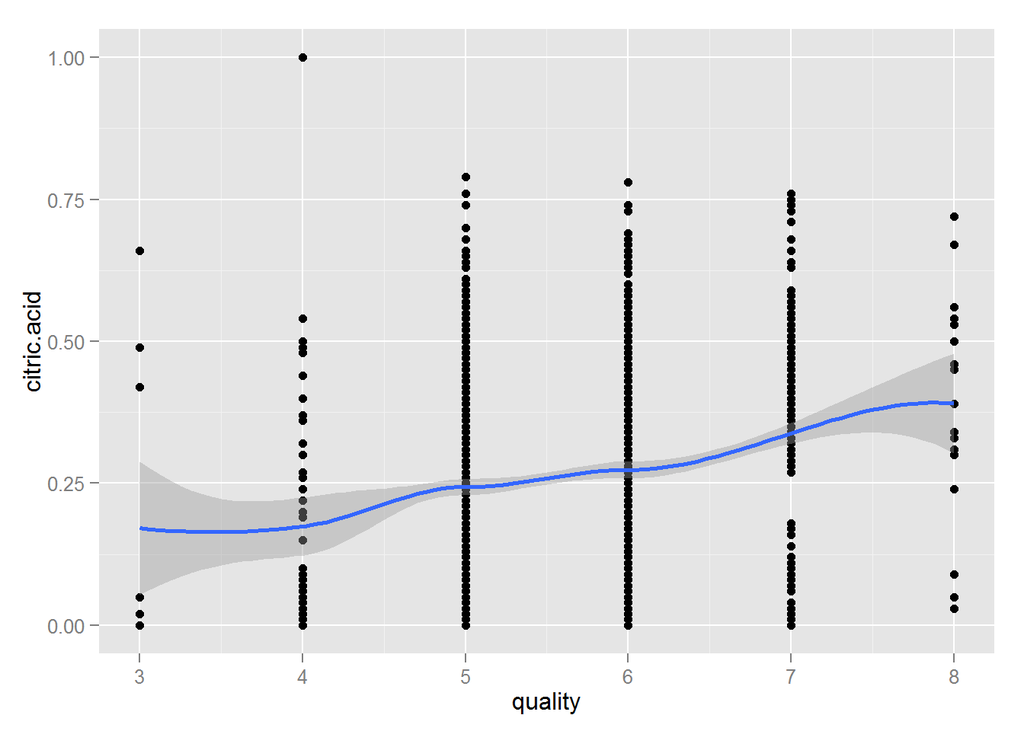

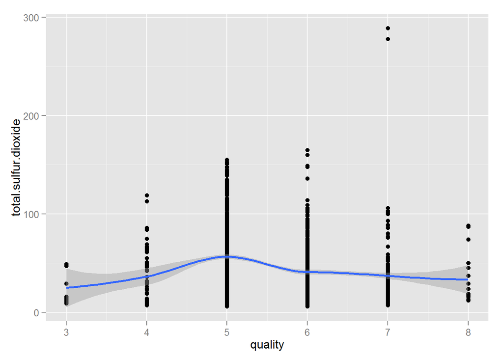

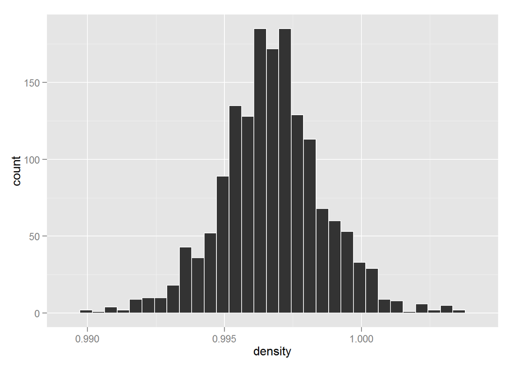

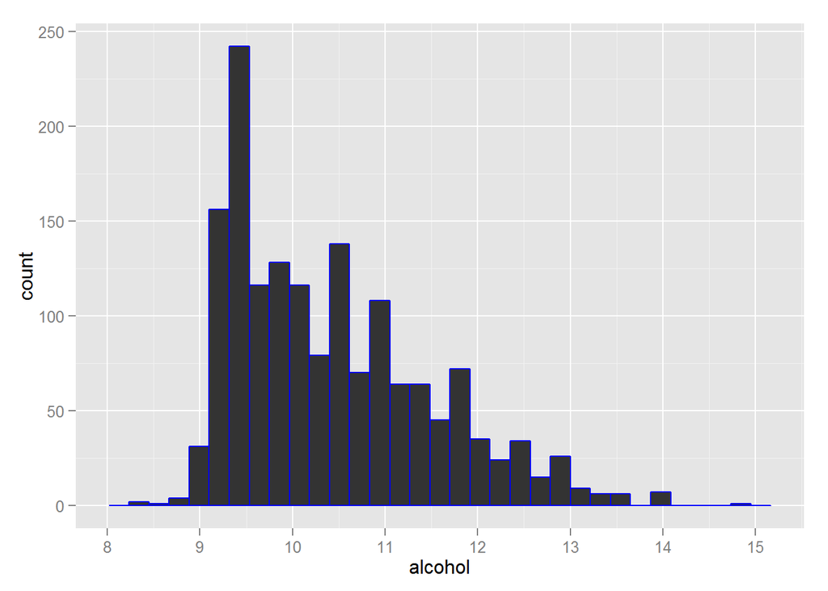

# Univariate Analysis

### What is/are the main feature(s) of interest in your dataset?

The main feature of interest is the quality score in the dataset.Each expert graded the wine quality between 0 (very bad) and 10 (very excellent), by exploring the MIN and MAX no experts gave any very bad or very excellent scores, techically the dataset shows on 3-8 quality scores.

### What other features in the dataset do you think will help support your investigation into your feature(s) of interest?

I think Alcohol will be important as it has a MIN is 8.40, while the MAX is 14.90. My early assumption is high alchol means higher quality, but we will have to explore further to prove that theory.

### Did you create any new variables from existing variables in the dataset?

Yes I converted free.sulfur.dioxide and total.sulfur.dioxide to grams as the dataset was in milligrams. The new variables were name gfree.sulfur.dioxide and gtotal.sulfur.dioxide. I was hoping the conversion would give all the features a level playing field to compare to other features.

### Of the features you investigated, were there any unusual distributions? Did you perform any operations on the data to tidy, adjust, or change the form of the data? If so, why did you do this?

Density and pH seemed to have the opposite distributions with the majority of the acid features. I always thought higher pH made water more, but I guess I was wrong. No changes were made to the data besides the two variables mentioned above.

# Bivariate Plots Section

```
##  [1] "X"                     "fixed.acidity"
##  [3] "volatile.acidity"      "citric.acid"
##  [5] "residual.sugar"        "chlorides"
##  [7] "free.sulfur.dioxide"   "total.sulfur.dioxide"
##  [9] "density"               "pH"
## [11] "sulphates"             "alcohol"
## [13] "quality"               "gfree.sulfur.dioxide"
## [15] "gtotal.sulfur.dioxide"
```

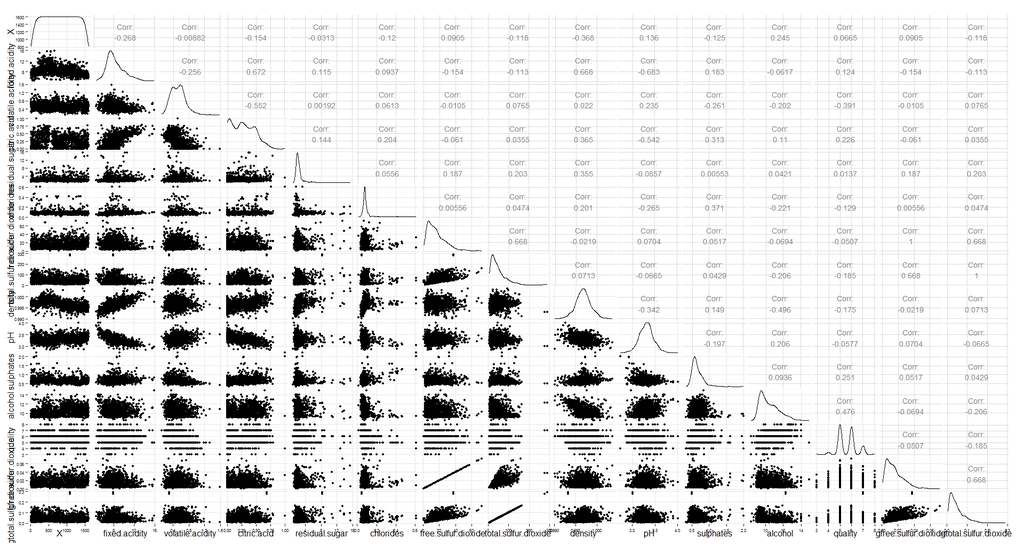

# Bivariate Analysis

### Talk about some of the relationships you observed in this part of the investigation. How did the feature(s) of interest vary with other features in the dataset?

From the scatterplot matrix we can observe these high correlations between these variables:  
Quality and Alcohol: 0.476  
Quality and Sulphates: 0.251  
Quality and Citric Acid: 0.226

### Did you observe any interesting relationships between the other features (not the main feature(s) of interest)?

I found pH and Density to be an interesting relationship seems they were affected with acid and sugar judging by thier scatterplots.

# Multivariate Plots Section

# Multivariate Analysis

### Talk about some of the relationships you observed in this part of the investigation. Were there features that strengthened each other in terms of looking at your feature(s) of interest?

Some more relationships are noted above in the charts. A particular one that stands out is that PH and Density have the opposite slope when graphed with some of the other features. Ph and Density did not have a large impact on the quality score compared to the other features.

### Were there any interesting or surprising interactions between features?

From the description of the variables we can get a hint into some clear relationships in the chemistry as it may times one chemical bonds with another. For example the density of water is close to that of water depending on the percent alcohol and sugar content. We can see the density plot histogram looks like a bell curve.

# Final Plots and Summary

### Plot One

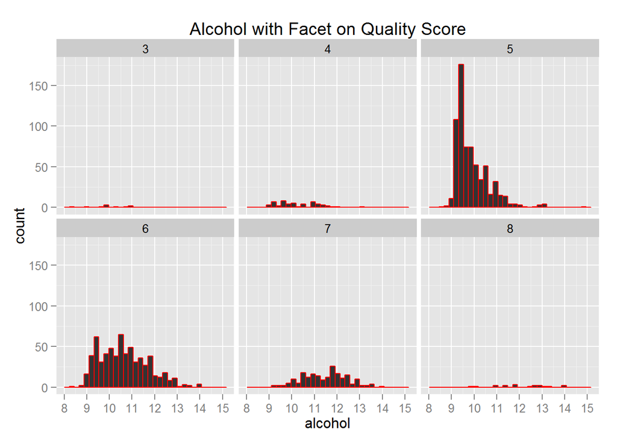

### Description One

Here we can see the distribution of Alcohol content to Quality Scores. we can see the scales slides to the right as the quality score increases.

### Plot Two

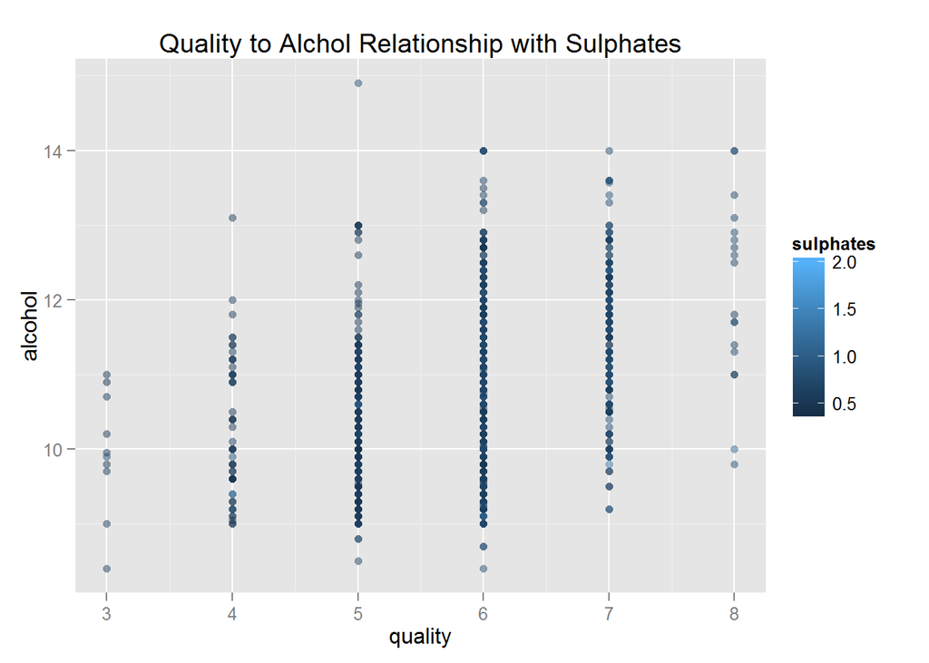

### Plot Three

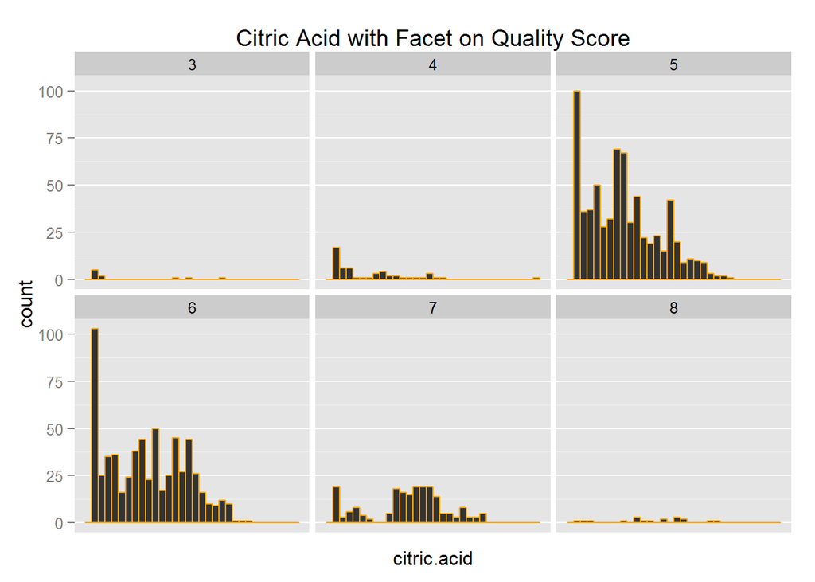

# Reflection

In the dataset I struggled with some of the chemistry, there might have been more ways for me to explore and utilize this data if I had a better chemistry background. Another struggle was there was no non numeric data in the dataset. In another analysis it might be good to categories the wines into subsets to explore them further.

An idea for the future would be to combine the insights learned in this dataset with other datasets on wine. I noticed other organizations rate wine on a scale of 1-100 and don’t get so complex with the chemistry in the features.Also noticed this data is missing the key detail of how long the wine has aged, wonder if this can someone be calculated through combining a few features. From my experience with wine, the older it is the better it tastes and that would be a key insight for this dataset if it was available.

# References

http://www.sthda.com/english/wiki/ggplot2-themes-and-background-colors-the-3-elements

http://www.ats.ucla.edu/stat/r/faq/smooths.htm